# IP_week12

2022-07-15

## *Online cryptography course advertising*

*Specifying the Data Analytic Question*

> As a Data Science Consultant, I have been employed by an online cryptography course entrepreneur to help her identify which individuals are most likely to click on her ads.

*Defining the Metric for Success* > Identifying which individuals are most likely to click on her ads

*Understanding the context*

> A Kenyan entrepreneur has created an online cryptography course and would want to advertise it on her blog. She currently targets audiences originating from various countries. She would like to identify which individuals are most likely to click on her ads.

*Recording the Experimental Design* > * Reading the Data * Tidying the Dataset * Exploratory Analysis * Implementing the Solution * Challenging the solution * Follow-up questions

*Data Relevance* > All the variables given are relevant to the entrepreneur and will help know more the how the online course advertisement was recieved

## *Reading and checking the data*

```r
# downloading tidyverse packages and library
install.packages('tidyverse', repos = "http://cran.us.r-project.org")
library(tidyverse)
#Read the dataset

advert <- read_csv("C://Users//Lenovo//Downloads//DB_prep//advertising.csv")
#Checking the head and tail of the data

head(advert)
```

| Daily Time Spent on Site | Age | Area Income | Daily Internet Usage | Ad Topic Line | City | Male | Country | Timestamp | Clicked on Ad |
| --- | --- | --- | --- | --- | --- | --- | --- | --- | --- |
| 68.95 | 35 | 61833.90 | 256.09 | Cloned 5thgeneration orchestration | Wrightburgh | 0 | Tunisia | 2016-03-27 00:53:11 | 0 |
| 80.23 | 31 | 68441.85 | 193.77 | Monitored national standardization | West Jodi | 1 | Nauru | 2016-04-04 01:39:02 | 0 |
| 69.47 | 26 | 59785.94 | 236.50 | Organic bottom-line service-desk | Davidton | 0 | San Marino | 2016-03-13 20:35:42 | 0 |
| 74.15 | 29 | 54806.18 | 245.89 | Triple-buffered reciprocal time-frame | West Terrifurt | 1 | Italy | 2016-01-10 02:31:19 | 0 |
| 68.37 | 35 | 73889.99 | 225.58 | Robust logistical utilization | South Manuel | 0 | Iceland | 2016-06-03 03:36:18 | 0 |
| 59.99 | 23 | 59761.56 | 226.74 | Sharable client-driven software | Jamieberg | 1 | Norway | 2016-05-19 14:30:17 | 0 |

```r
tail(advert)
```

| Daily Time Spent on Site | Age | Area Income | Daily Internet Usage | Ad Topic Line | City | Male | Country | Timestamp | Clicked on Ad |
| --- | --- | --- | --- | --- | --- | --- | --- | --- | --- |
| 43.70 | 28 | 63126.96 | 173.01 | Front-line bifurcated ability | Nicholasland | 0 | Mayotte | 2016-04-04 03:57:48 | 1 |
| 72.97 | 30 | 71384.57 | 208.58 | Fundamental modular algorithm | Duffystad | 1 | Lebanon | 2016-02-11 21:49:00 | 1 |
| 51.30 | 45 | 67782.17 | 134.42 | Grass-roots cohesive monitoring | New Darlene | 1 | Bosnia and Herzegovina | 2016-04-22 02:07:01 | 1 |
| 51.63 | 51 | 42415.72 | 120.37 | Expanded intangible solution | South Jessica | 1 | Mongolia | 2016-02-01 17:24:57 | 1 |
| 55.55 | 19 | 41920.79 | 187.95 | Proactive bandwidth-monitored policy | West Steven | 0 | Guatemala | 2016-03-24 02:35:54 | 0 |
| 45.01 | 26 | 29875.80 | 178.35 | Virtual 5thgeneration emulation | Ronniemouth | 0 | Brazil | 2016-06-03 21:43:21 | 1 |

```r
# Lists variables in the dataset
names(advert)
```

```
##  [1] "Daily Time Spent on Site" "Age"
##  [3] "Area Income"              "Daily Internet Usage"
##  [5] "Ad Topic Line"            "City"
##  [7] "Male"                     "Country"
##  [9] "Timestamp"                "Clicked on Ad"
```

```r
# Seeing the structure of the dataset
str(advert)
```

```
## spec_tbl_df [1,000 × 10] (S3: spec_tbl_df/tbl_df/tbl/data.frame)
##  $ Daily Time Spent on Site: num [1:1000] 69 80.2 69.5 74.2 68.4 ...
##  $ Age                     : num [1:1000] 35 31 26 29 35 23 33 48 30 20 ...
##  $ Area Income             : num [1:1000] 61834 68442 59786 54806 73890 ...
##  $ Daily Internet Usage    : num [1:1000] 256 194 236 246 226 ...
##  $ Ad Topic Line           : chr [1:1000] "Cloned 5thgeneration orchestration" "Monitored national standardization" "Organic bottom-line service-desk" "Triple-buffered reciprocal time-frame" ...
##  $ City                    : chr [1:1000] "Wrightburgh" "West Jodi" "Davidton" "West Terrifurt" ...
##  $ Male                    : num [1:1000] 0 1 0 1 0 1 0 1 1 1 ...
##  $ Country                 : chr [1:1000] "Tunisia" "Nauru" "San Marino" "Italy" ...
##  $ Timestamp               : POSIXct[1:1000], format: "2016-03-27 00:53:11" "2016-04-04 01:39:02" ...
##  $ Clicked on Ad           : num [1:1000] 0 0 0 0 0 0 0 1 0 0 ...
##  - attr(*, "spec")=
##   .. cols(
##   ..   `Daily Time Spent on Site` = col_double(),
##   ..   Age = col_double(),
##   ..   `Area Income` = col_double(),
##   ..   `Daily Internet Usage` = col_double(),
##   ..   `Ad Topic Line` = col_character(),
##   ..   City = col_character(),
##   ..   Male = col_double(),
##   ..   Country = col_character(),
##   ..   Timestamp = col_datetime(format = ""),
##   ..   `Clicked on Ad` = col_double()
##   .. )
##  - attr(*, "problems")=<externalptr>
```

```r
#The rows and columns in the data
cat("The dataset has ", dim(advert)[1], "rows and ", dim(advert)[2], " columns")
```

```
## The dataset has  1000 rows and  10  columns
```

```r
#checking the datatypes on the columns
sapply(advert, class)
```

```
## $`Daily Time Spent on Site`
## [1] "numeric"
##
## $Age
## [1] "numeric"
##
## $`Area Income`
## [1] "numeric"
##
## $`Daily Internet Usage`
## [1] "numeric"
##
## $`Ad Topic Line`
## [1] "character"
##
## $City
## [1] "character"
##
## $Male
## [1] "numeric"
##
## $Country
## [1] "character"
##
## $Timestamp
## [1] "POSIXct" "POSIXt"
##
## $`Clicked on Ad`
## [1] "numeric"
```

```r
#summary of the dataset
#Basic descriptive statistics and frequencies.

summary(advert)
```

```
##  Daily Time Spent on Site      Age         Area Income    Daily Internet Usage
##  Min.   :32.60            Min.   :19.00   Min.   :13996   Min.   :104.8
##  1st Qu.:51.36            1st Qu.:29.00   1st Qu.:47032   1st Qu.:138.8
##  Median :68.22            Median :35.00   Median :57012   Median :183.1
##  Mean   :65.00            Mean   :36.01   Mean   :55000   Mean   :180.0
##  3rd Qu.:78.55            3rd Qu.:42.00   3rd Qu.:65471   3rd Qu.:218.8
##  Max.   :91.43            Max.   :61.00   Max.   :79485   Max.   :270.0
##  Ad Topic Line          City                Male         Country
##  Length:1000        Length:1000        Min.   :0.000   Length:1000
##  Class :character   Class :character   1st Qu.:0.000   Class :character
##  Mode  :character   Mode  :character   Median :0.000   Mode  :character
##                                        Mean   :0.481
##                                        3rd Qu.:1.000
##                                        Max.   :1.000
##    Timestamp                      Clicked on Ad
##  Min.   :2016-01-01 02:52:10.00   Min.   :0.0
##  1st Qu.:2016-02-18 02:55:42.00   1st Qu.:0.0
##  Median :2016-04-07 17:27:29.50   Median :0.5
##  Mean   :2016-04-10 10:34:06.64   Mean   :0.5
##  3rd Qu.:2016-05-31 03:18:14.00   3rd Qu.:1.0
##  Max.   :2016-07-24 00:22:16.00   Max.   :1.0
```

## Tidying the dataset

```r
## Importing packages for plotting

library(tidyr)
library(ggplot2)
library(dplyr)
```

```r
names(advert)<- tolower(names(advert)) # make the column names to lowercase
```

```r
names(advert)<- str_replace_all(names(advert), c(" " = "_")) # Replacing the white spaces in the column names

head(advert)
```

| daily_time_spent_on_site | age | area_income | daily_internet_usage | ad_topic_line | city | male | country | timestamp | clicked_on_ad |
| --- | --- | --- | --- | --- | --- | --- | --- | --- | --- |
| 68.95 | 35 | 61833.90 | 256.09 | Cloned 5thgeneration orchestration | Wrightburgh | 0 | Tunisia | 2016-03-27 00:53:11 | 0 |
| 80.23 | 31 | 68441.85 | 193.77 | Monitored national standardization | West Jodi | 1 | Nauru | 2016-04-04 01:39:02 | 0 |
| 69.47 | 26 | 59785.94 | 236.50 | Organic bottom-line service-desk | Davidton | 0 | San Marino | 2016-03-13 20:35:42 | 0 |
| 74.15 | 29 | 54806.18 | 245.89 | Triple-buffered reciprocal time-frame | West Terrifurt | 1 | Italy | 2016-01-10 02:31:19 | 0 |
| 68.37 | 35 | 73889.99 | 225.58 | Robust logistical utilization | South Manuel | 0 | Iceland | 2016-06-03 03:36:18 | 0 |
| 59.99 | 23 | 59761.56 | 226.74 | Sharable client-driven software | Jamieberg | 1 | Norway | 2016-05-19 14:30:17 | 0 |

```r
# Creating a Subset
df <-subset(advert, select = -c(    city,male,  country,ad_topic_line, timestamp)) # selects Age    ,Area.Income    ,Daily.Internet.Usage,  Clicked.on.Ad
print("Modified Data Frame")
```

```
## [1] "Modified Data Frame"
```

```r
head(df)
```

| daily_time_spent_on_site | age | area_income | daily_internet_usage | clicked_on_ad |
| --- | --- | --- | --- | --- |
| 68.95 | 35 | 61833.90 | 256.09 | 0 |
| 80.23 | 31 | 68441.85 | 193.77 | 0 |
| 69.47 | 26 | 59785.94 | 236.50 | 0 |
| 74.15 | 29 | 54806.18 | 245.89 | 0 |
| 68.37 | 35 | 73889.99 | 225.58 | 0 |
| 59.99 | 23 | 59761.56 | 226.74 | 0 |

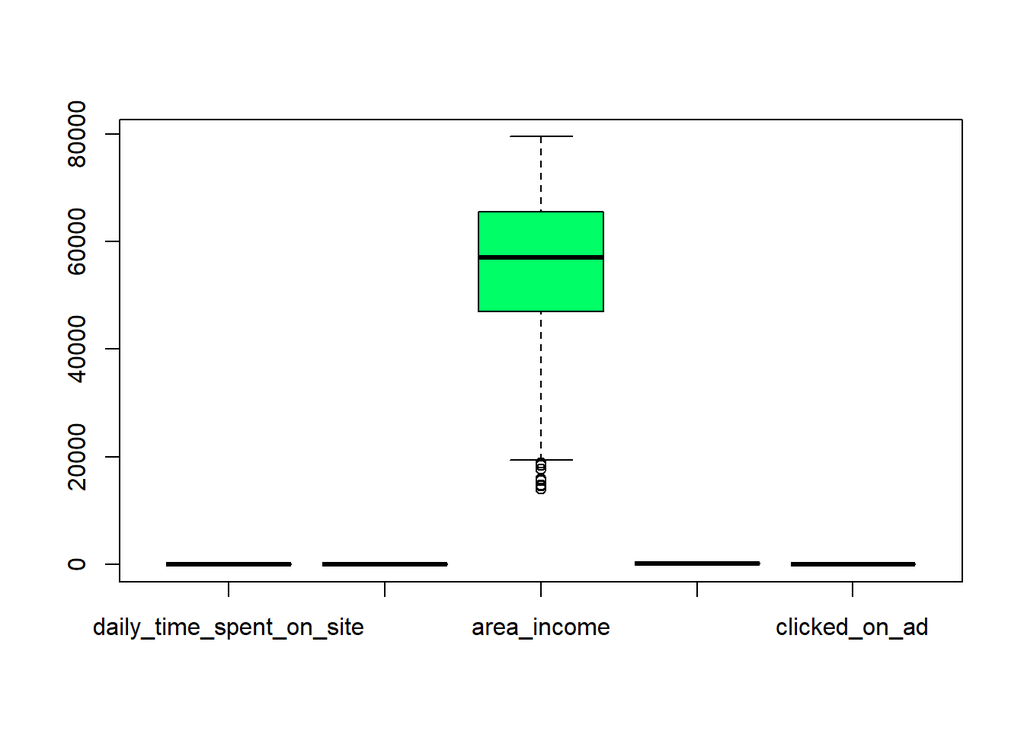

```r
#Checking for outliers
boxplot(df, col = rainbow(ncol(df)))
```

The area income has outliers only

```r
# Listing the outliers
OutVals = boxplot(df, plot=FALSE)$out
OutVals
```

```
## [1] 17709.98 18819.34 15598.29 15879.10 14548.06 13996.50 14775.50 18368.57
```

```r
#Removing outliers
advert1 <-advert

advert1<- advert1[-which(advert1$area_income %in% OutVals),]
#check the difference
print(dim(advert))
```

```
## [1] 1000   10
```

```r
print(dim(advert1))
```

```
## [1] 992  10
```

```r
#Checking for duplicates in data

duplicated_rows <- advert1[duplicated(advert1),]
duplicated_rows
```

| daily_time_spent_on_site | age | area_income | daily_internet_usage | ad_topic_line | city | male | country | timestamp | clicked_on_ad |
| --- | --- | --- | --- | --- | --- | --- | --- | --- | --- |

No duplicates

```r
# Checking the number of missing per column/variable
colSums(is.na(advert1))
```

```
## daily_time_spent_on_site                      age              area_income
##                        0                        0                        0
##     daily_internet_usage            ad_topic_line                     city
##                        0                        0                        0
##                     male                  country                timestamp
##                        0                        0                        0
##            clicked_on_ad
##                        0
```

No missing data in any column

## *Exploratory data analysis*

## *Univariate analysis*

*Measures of Central Tendency*

```r
#Checking the mean
advert1.dist.mean <- colMeans(subset(advert1, select = c(daily_time_spent_on_site,age,  area_income,    daily_internet_usage)), na.rm = TRUE)
advert1.dist.mean
```

```
## daily_time_spent_on_site                      age              area_income
##                 65.03979                 35.98286              55312.80720
##     daily_internet_usage
##                179.98504
```

The mean age of those that visited the blog was 35, and on average the daily time spent was 65 minutes, and the average area income of those that visited the blog was 55312 and had average data usage of 179.98

```r
# Check for median

advert1.dist.median <- apply(subset(advert1, select = c(daily_time_spent_on_site,age,   area_income,    daily_internet_usage)),2,median, na.rm = TRUE)
advert1.dist.median
```

```
## daily_time_spent_on_site                      age              area_income
##                   68.390                   35.000                57228.185
##     daily_internet_usage
##                  183.425
```

The median age of those that visited the blog was 35, and on median daily time spent was 68 minutes, and the median area income of those that visited the blog was 57228.185 and had a data usage of 183.425

## Measures of dispersion

```r
#check the minimum values of every column
advert.dist.min <- apply(subset(advert1, select = c(daily_time_spent_on_site,age,   area_income,    daily_internet_usage)),2,min, na.rm = TRUE)
advert.dist.min
```

```
## daily_time_spent_on_site                      age              area_income
##                    32.60                    19.00                 19345.36
##     daily_internet_usage
##                   104.78
```

The minimum age of those that visit her blog is 19 years and minimum time spent on site is 32 and the minimum area income is 19345.6 and the minimum internet usage is 104.78

```r
#check the maximum values of every column
advert.dist.max <- apply(subset(advert1, select = c(daily_time_spent_on_site,age,   area_income,    daily_internet_usage)),2,max, na.rm = TRUE)
advert.dist.max
```

```
## daily_time_spent_on_site                      age              area_income
##                    91.43                    61.00                 79484.80
##     daily_internet_usage
##                   269.96
```

```r
#check the range of  values of every column
advert.dist.range <- apply(subset(advert1, select = c(daily_time_spent_on_site, age,    area_income,    daily_internet_usage)),2,range, na.rm = TRUE)
advert.dist.range
```

```
##      daily_time_spent_on_site age area_income daily_internet_usage
## [1,]                    32.60  19    19345.36               104.78
## [2,]                    91.43  61    79484.80               269.96
```

```r
#check the quantiles  values of every column
advert.dist.quantiles <- apply(subset(advert1, select = c(daily_time_spent_on_site,age, area_income,    daily_internet_usage)),2,quantile, na.rm = TRUE)
advert.dist.quantiles
```

```
##      daily_time_spent_on_site age area_income daily_internet_usage
## 0%                     32.600  19    19345.36             104.7800
## 25%                    51.285  29    47332.82             138.6475
## 50%                    68.390  35    57228.18             183.4250
## 75%                    78.585  42    65518.96             218.8425
## 100%                   91.430  61    79484.80             269.9600
```

```r
#check the variation of  values of every column
#The variance is a numerical measure of how the data values is dispersed around the mean.

advert.dist.variance <- apply(subset(advert1, select = c(daily_time_spent_on_site, age, area_income,    daily_internet_usage)),2,var, na.rm = TRUE)
advert.dist.variance
```

```
## daily_time_spent_on_site                      age              area_income
##             2.528609e+02             7.745379e+01             1.691376e+08
##     daily_internet_usage
##             1.938785e+03
```

```r
#check the standard deviation of  values of every column
#Standard deviation tells you how spread out the data is. It is a measure of how far each observed value is from the mean.

advert.dist.sd <- apply(subset(advert1, select = c(daily_time_spent_on_site,age,    area_income,    daily_internet_usage)),2,sd, na.rm = TRUE)
advert.dist.sd
```

```
## daily_time_spent_on_site                      age              area_income
##                15.901600                 8.800784             13005.290554
##     daily_internet_usage
##                44.031632
```

Area income values are highly spread out from the mean

```r
#check the skewness every column
install.packages("moments", repos = "http://cran.us.r-project.org")
library(moments)
advert.dist.skewness <- apply(subset(advert1, select = c(daily_time_spent_on_site,age,  area_income,    daily_internet_usage)),2,skewness, na.rm = TRUE)
advert.dist.skewness
```

```
## daily_time_spent_on_site                      age              area_income
##              -0.37679250               0.48509707              -0.57508362
##     daily_internet_usage
##              -0.03390524
```

```r
#check the kurtosis every column
#install.packages("moments")
#library(moments)

advert.dist.kurtosis <- apply(subset(advert1, select = c(daily_time_spent_on_site,age,  area_income,    daily_internet_usage)),2,kurtosis, na.rm = TRUE)
advert.dist.kurtosis
```

```
## daily_time_spent_on_site                      age              area_income
##                 1.898712                 2.599489                 2.708115
##     daily_internet_usage
##                 1.719177
```

A distribution with kurtosis <3 like for all our variables is called platykurtic. Compared to a normal distribution, its tails are shorter and thinner, and often its central peak is lower and broader.

The reason for this is because the extreme values are less than that of the normal distribution.

## Univariate graphical

A histogram shows the frequency distribution of a quantitative variable. The area of each bar is equal to the frequency of items found in each class.

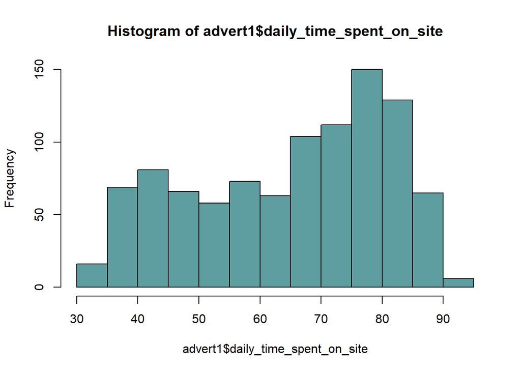

```r
#see the daily_time_spent_on_site distribution
hist(advert1$daily_time_spent_on_site, col='cadetblue')
```

Most people spend around 70-85 daily time on the blog

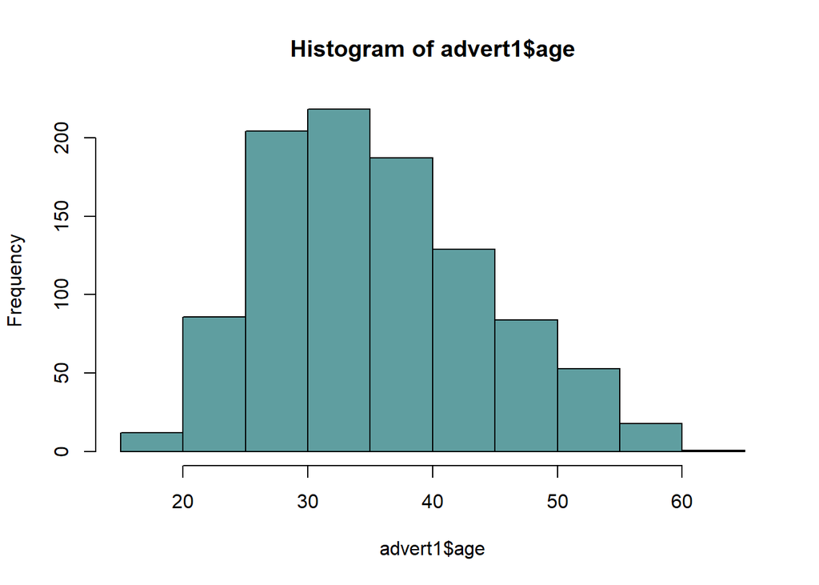

```r
#See the age distribution
hist(advert1$age, col='cadetblue')
```

Most people that spend time on the blog are between 25-35 years

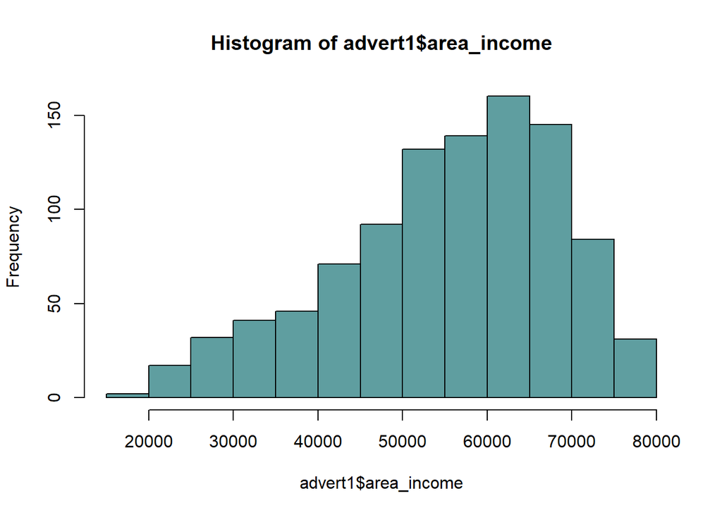

```r
#See the area_income distribution
hist(advert1$area_income, col='cadetblue')
```

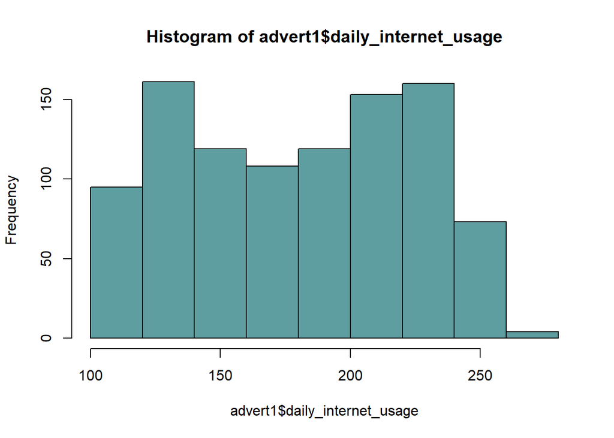

```r
#See the daily_internet_usage distribution
hist(advert1$daily_internet_usage, col='cadetblue')
```

Most daily internet usage in the blog is around 120-140 and 220-240

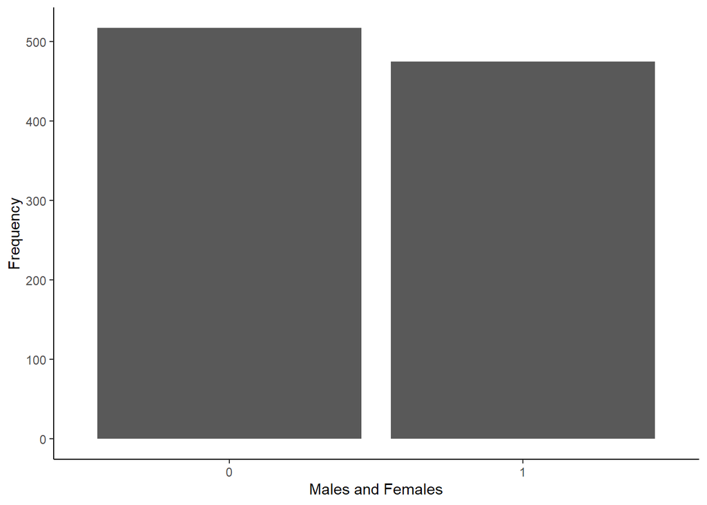

```r
ggplot(advert1,aes(x=toupper(male)))+geom_bar()+xlab(label = "Males and Females")+ylab(label = "Frequency")+theme_classic()
```

female is 0 hence most people on her blog are female

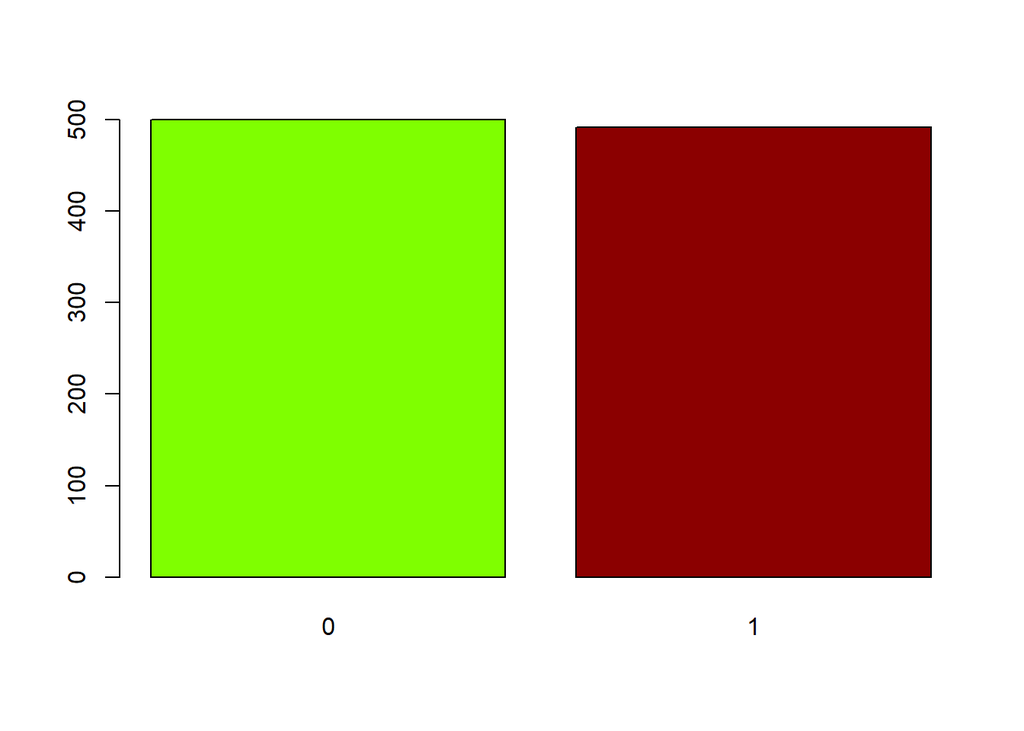

```r
# Getting specific columns which is clicked on ad
clickad <- advert1$clicked_on_ad

# Applying the table() function will compute the frequency distribution of the male variable
# ---
#
clicked_ad_frequency <- table(clickad)


# Then applying the barplot function to produce its bar graph
# ---
#
barplot(clicked_ad_frequency, col=c("chartreuse", "red4"))
```

The number of people that click the ad on the blog are almost equal

```r
#Distribution of the countries
table(advert1$country)
```

```
##
##                                         Afghanistan
##                                                   8
##                                             Albania
##                                                   7
##                                             Algeria
##                                                   5
##                                      American Samoa
##                                                   5
##                                             Andorra
##                                                   2
##                                              Angola
##                                                   4
##                                            Anguilla
##                                                   6
##        Antarctica (the territory South of 60 deg S)
##                                                   3
##                                 Antigua and Barbuda
##                                                   5
##                                           Argentina
##                                                   2
##                                             Armenia
##                                                   3
##                                               Aruba
##                                                   1
##                                           Australia
##                                                   8
##                                             Austria
##                                                   5
##                                          Azerbaijan
##                                                   2
##                                             Bahamas
##                                                   7
##                                             Bahrain
##                                                   5
##                                          Bangladesh
##                                                   4
##                                            Barbados
##                                                   5
##                                             Belarus
```

[output cut: 420 more lines]

```
##                                                   6
##                                           Venezuela
##                                                   7
##                                             Vietnam
##                                                   3
##                                   Wallis and Futuna
##                                                   4
##                                      Western Sahara
##                                                   7
##                                               Yemen
##                                                   3
##                                              Zambia
##                                                   4
##                                            Zimbabwe
##                                                   6
```

```r
tt = table(advert1$country)
max(tt)
```

```
## [1] 9
```

France have the most people that visited the blog

```r
#Distribution of cities
table(advert1$city)
```

```
##
##               Adamsbury                Adamside               Adamsstad
##                       1                       1                       1
##                Alanview           Alexanderfurt           Alexanderview
##                       1                       1                       1
##           Alexandrafort              Alexisland              Aliciatown
##                       1                       1                       1
##            Alvaradoport             Alvarezland              Amandafort
##                       1                       1                       1
##             Amandahaven              Amandaland                 Amyfurt
##                       1                       1                       1
##                Amyhaven         Andersonchester            Andersonfurt
##                       1                       1                       1
##             Andersonton           Andrewborough             Andrewmouth
##                       1                       1                       1
##              Angelhaven             Anthonyfurt           Ashleychester
##                       1                       1                       1
##             Ashleymouth           Austinborough              Austinland
##                       1                       1                       1
##              Bakerhaven             Barbershire                 Beckton
##                       1                       1                       1
##         Benjaminchester              Bernardton               Bethburgh
##                       2                       1                       1
##               Birdshire            Blairborough              Blairville
##                       1                       1                       1
##             Blevinstown               Bowenview               Boyerberg
##                       1                       1                       1
##          Bradleyborough            Bradleyburgh             Bradleyside
##                       1                       1                       1
##         Bradshawborough               Bradyfurt              Brandiland
##                       1                       1                       1
##             Brandonbury             Brandonstad             Brandymouth
##                       1                       1                       1
##             Brendaburgh           Brendachester              Brianabury
##                       1                       1                       1
##               Brianfurt               Brianland         Brittanyborough
##                       1                       1                       1
##               Brownbury               Brownport                Brownton
##                       1                       1                       1
##               Browntown               Brownview              Bruceburgh
```

[output cut: 588 more lines]

```
##                       1                       1                       1
##            Williammouth             Williamport         Williamsborough
##                       1                       1                       1
##            Williamsfort           Williamsmouth            Williamsport
##                       1                       1                       3
##            Williamsside             Williamstad             Wilsonburgh
##                       1                       1                       1
##             Wintersfort                Wongland             Wrightburgh
##                       1                       1                       2
##              Wrightview                Yangside              Youngburgh
##                       1                       1                       1
##               Youngfort                   Yuton             Zacharystad
##                       1                       1                       1
##              Zacharyton
##                       1
```

Very few cities had more that one person visiting the site

```r
#Distribution of cities
table(advert1$ad_topic_line)
```

```
##
##                       Adaptive 24hour Graphic Interface
##                                                       1
##                          Adaptive asynchronous attitude
##                                                       1
##                  Adaptive context-sensitive application
##                                                       1
##                 Adaptive contextually-based methodology
##                                                       1
##                    Adaptive demand-driven knowledgebase
##                                                       1
##                             Adaptive uniform capability
##                                                       1
##                              Advanced 24/7 productivity
##                                                       1
##                       Advanced 5thgeneration capability
##                                                       1
##                        Advanced didactic conglomeration
##                                                       1
##                 Advanced disintermediate data-warehouse
##                                                       1
##                         Advanced exuding conglomeration
##                                                       1
##                           Advanced full-range migration
##                                                       1
##                             Advanced heuristic firmware
##                                                       1
##                               Advanced local task-force
##                                                       1
##                     Advanced modular Local Area Network
##                                                       1
##                          Advanced systemic productivity
##                                                       1
##                    Advanced web-enabled standardization
##                                                       1
##                         Ameliorated actuating workforce
##                                                       1
##             Ameliorated bandwidth-monitored contingency
##                                                       1
##                      Ameliorated client-driven forecast
```

[output cut: 1930 more lines]

```
##                                                       1
##                           Visionary analyzing structure
##                                                       1
##                         Visionary asymmetric encryption
##                                                       1
##                    Visionary client-driven installation
##                                                       1
##                 Visionary maximized process improvement
##                                                       1
##                  Visionary mission-critical application
##                                                       1
##                        Visionary multi-tasking alliance
##                                                       1
##                            Visionary reciprocal circuit
##                                                       1
```

## *Bivariate analysis*

```r
names(advert1)
```

```
##  [1] "daily_time_spent_on_site" "age"
##  [3] "area_income"              "daily_internet_usage"
##  [5] "ad_topic_line"            "city"
##  [7] "male"                     "country"
##  [9] "timestamp"                "clicked_on_ad"
```

```r
#Assigning the each column to the  their variable for easier manipulation

age <- advert1$age

daily_time_spent_on_site <- advert1$daily_time_spent_on_site

area_income <- advert1$area_income

daily_internet_usage <- advert1$daily_internet_usage
```

*Covariance of various variables*

Age and other variables

```r
cov(age, daily_time_spent_on_site)
```

```
## [1] -46.5009
```

```r
cov(age, area_income)
```

```
## [1] -20614.92
```

```r
cov(age, daily_internet_usage)
```

```
## [1] -142.5798
```

Area income and other variables

```r
cov( area_income, daily_time_spent_on_site)
```

```
## [1] 65151.28
```

```r
cov( area_income, daily_internet_usage)
```

```
## [1] 200896.3
```

Daily internet usage and daily time spent

```r
cov( daily_time_spent_on_site, daily_internet_usage)
```

```
## [1] 363.8961
```

Covariance indicates the relationship of two variables whenever one variable changes.

If an increase in one variable results in an increase in the other variable, both variables are said to have a positive covariance.

Area income and daily time spent, area income and daily internet usage and daily internet usage and daily internet usage have positive covariance

Decreases in one variable also cause a decrease in the other. Both variables move together in the same direction when they change.

Age and the other variables have negative covariance

*Correlation Coefficient*

```r
cor(age, daily_time_spent_on_site)
```

```
## [1] -0.3322762
```

```r
cor(age, area_income)
```

```
## [1] -0.180111
```

```r
cor(age, daily_internet_usage)
```

```
## [1] -0.3679358
```

```r
cor( area_income, daily_time_spent_on_site)
```

```
## [1] 0.3150374
```

```r
cor( area_income, daily_internet_usage)
```

```
## [1] 0.3508222
```

```r
cor( daily_time_spent_on_site, daily_internet_usage)
```

```
## [1] 0.5197228
```

Age and other variables are weakly negatively linearly related

While daily time spent on site and daily internet usage has the highest positive linearly relationship

*Correlation matrix*

```r
install.packages("corrplot", repos = "http://cran.us.r-project.org") # used to draw correlation matrix
```

Plotting a correlation matrix

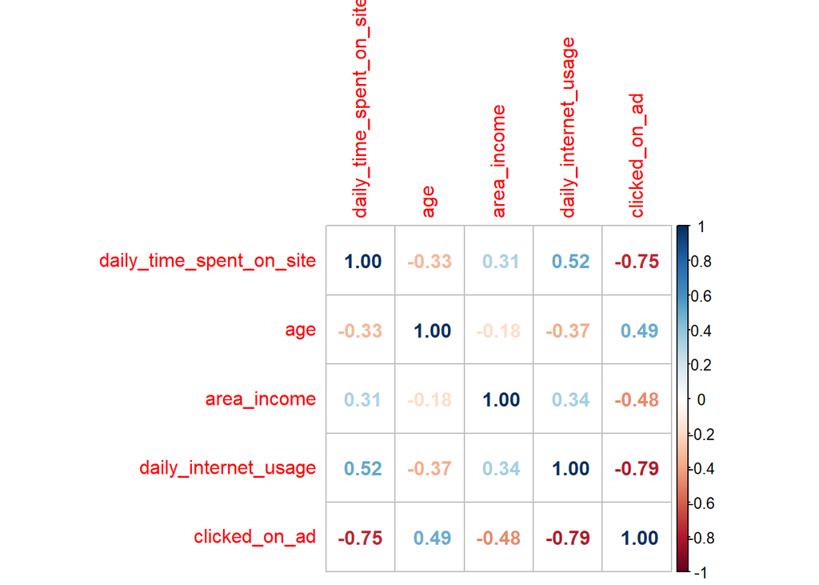

```r
M<-cor(df) #find the correlation
library(corrplot)
corrplot(M, method="number") #Compute and visualize the correlation coefficients
```

Those with blue have positive correlation coefficient while those in red have negative correlation coefficient

*Scatter plot*

Area income and internet usage

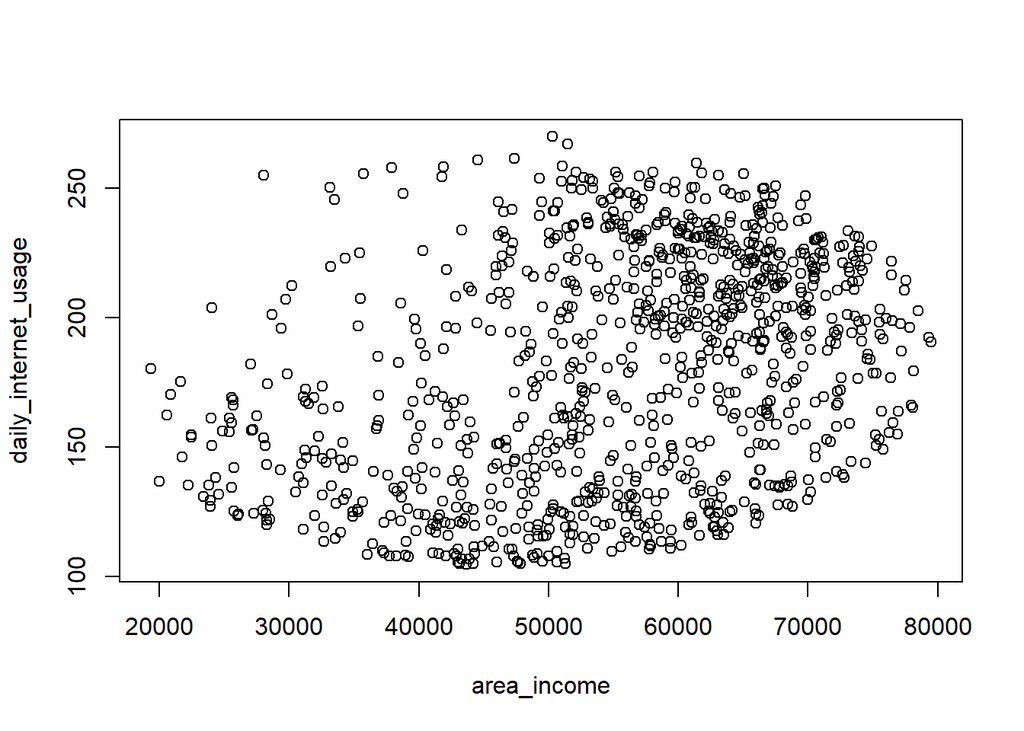

```r
plot(area_income,daily_internet_usage,  xlab="area_income", ylab="daily_internet_usage")
```

Age and Internet usage

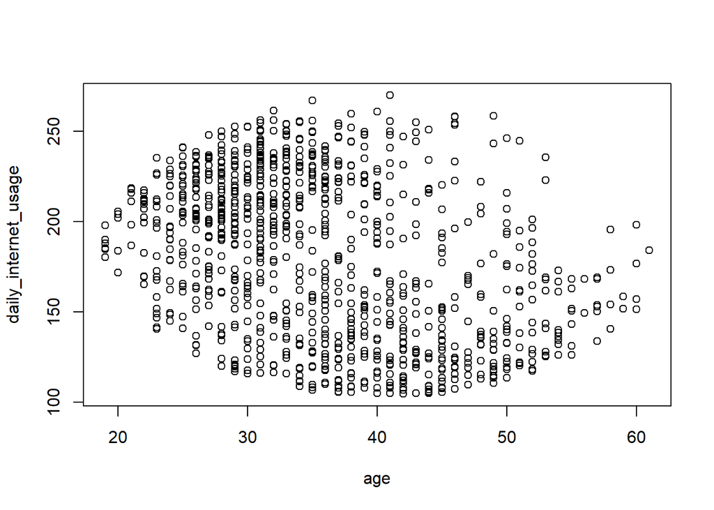

```r
plot(age,daily_internet_usage,  xlab="age", ylab="daily_internet_usage")
```

The scatter plots above reveals a weak relationships between area_internet and internet_usage and age and internet_usage

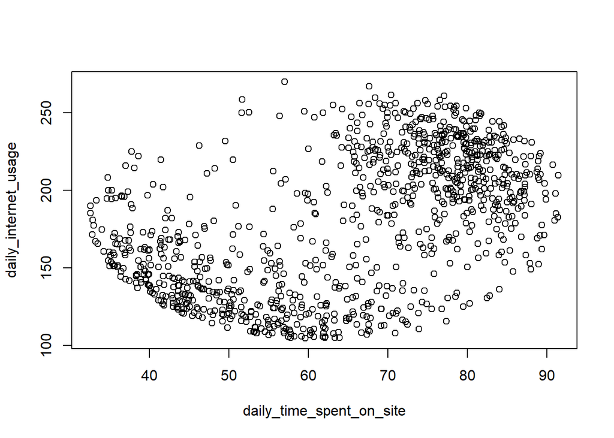

```r
plot(daily_time_spent_on_site,daily_internet_usage,  xlab="daily_time_spent_on_site", ylab="daily_internet_usage")
```

## *Implementing the solution*

```r
#Create a dataframe that selects those that clicked an ad

yes <-  advert1 %>% filter(advert1$clicked_on_ad  == 1);   # Select those  clicked on ad
```

```r
#summary of those that clicked the ad
summary(yes)
```

```
##  daily_time_spent_on_site      age         area_income    daily_internet_usage
##  Min.   :32.60            Min.   :19.00   Min.   :19345   Min.   :104.8
##  1st Qu.:42.58            1st Qu.:34.00   1st Qu.:39697   1st Qu.:123.3
##  Median :51.27            Median :40.00   Median :49867   Median :138.5
##  Mean   :53.03            Mean   :40.35   Mean   :49141   Mean   :144.9
##  3rd Qu.:61.92            3rd Qu.:47.00   3rd Qu.:59403   3rd Qu.:160.4
##  Max.   :91.37            Max.   :61.00   Max.   :78521   Max.   :270.0
##  ad_topic_line          city                male          country
##  Length:492         Length:492         Min.   :0.0000   Length:492
##  Class :character   Class :character   1st Qu.:0.0000   Class :character
##  Mode  :character   Mode  :character   Median :0.0000   Mode  :character
##                                        Mean   :0.4573
##                                        3rd Qu.:1.0000
##                                        Max.   :1.0000
##    timestamp                      clicked_on_ad
##  Min.   :2016-01-01 15:14:24.00   Min.   :1
##  1st Qu.:2016-02-17 23:19:07.25   1st Qu.:1
##  Median :2016-04-07 20:36:22.00   Median :1
##  Mean   :2016-04-10 17:57:40.06   Mean   :1
##  3rd Qu.:2016-05-31 03:18:14.00   3rd Qu.:1
##  Max.   :2016-07-24 00:22:16.00   Max.   :1
```

The mean years of those that clicked the ad was 40years

The mean daily time of those that clicked the ad spent was 53

The area income mean of those that clicked the ad was 49141

The daily internet usage mean was 144.9

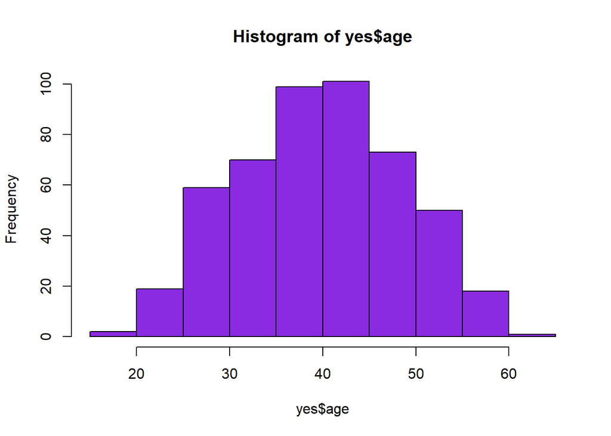

```r
#See the age distribution
hist(yes$age, col='blueviolet')
```

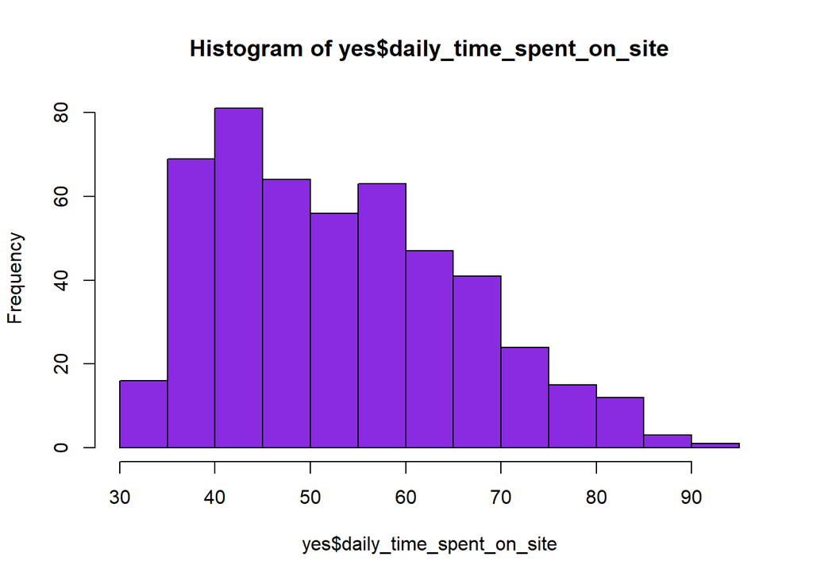

```r
#See the daily_time_spent_on_site distribution
hist(yes$daily_time_spent_on_site, col='blueviolet')
```

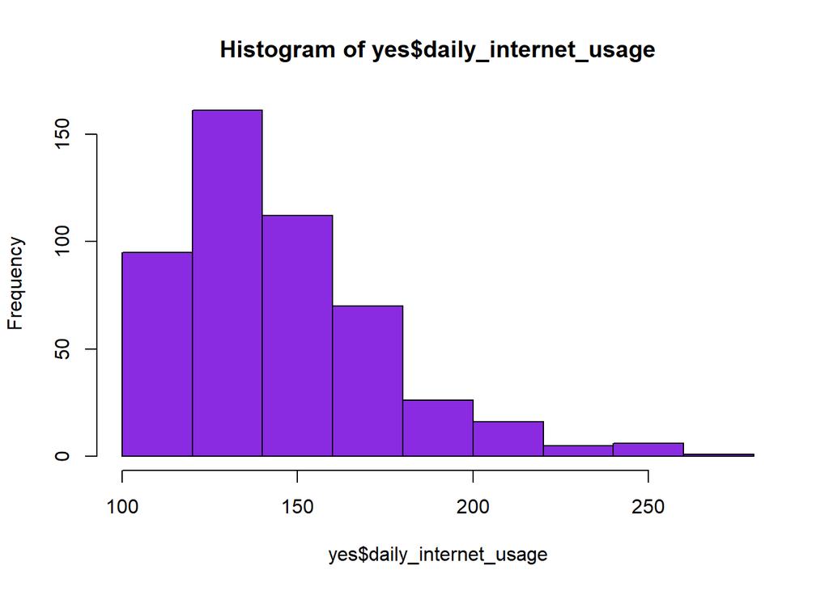

```r
#See the daily_internet_usage distribution
hist(yes$daily_internet_usage, col='blueviolet')
```

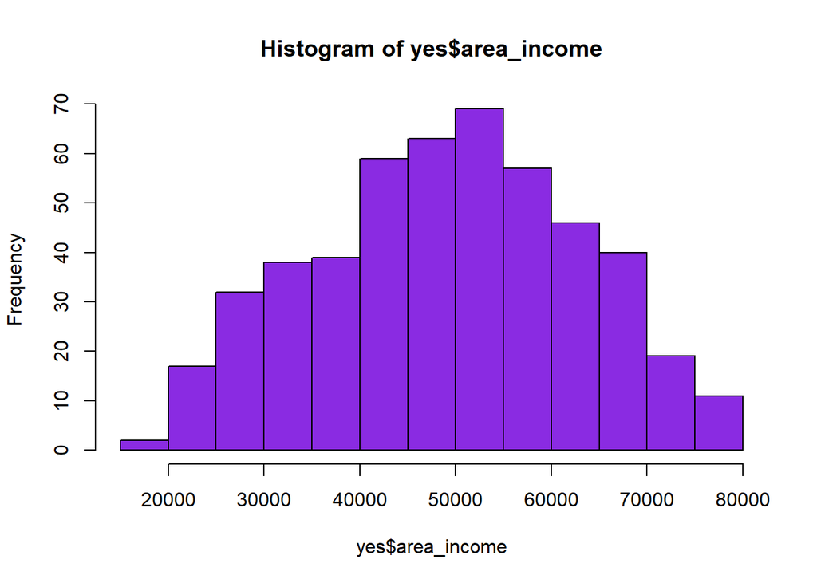

```r
#See the area_income distribution
hist(yes$area_income, col='blueviolet')
```

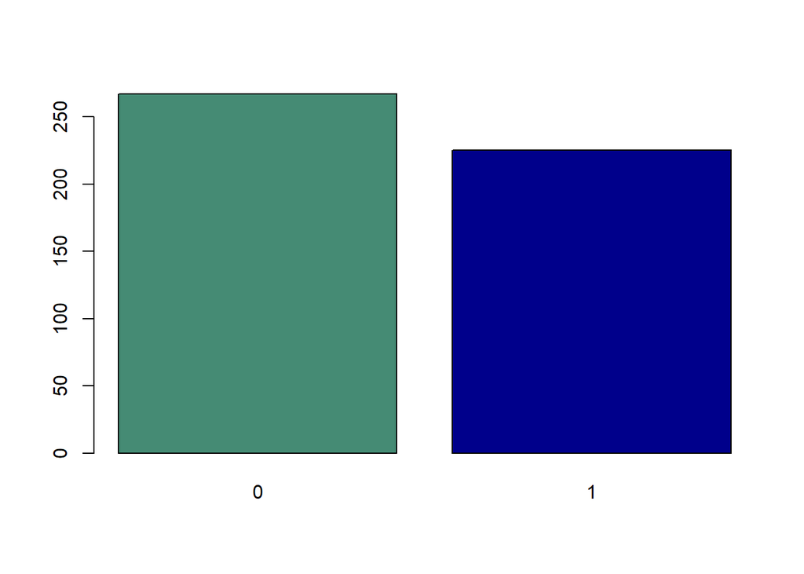

```r
# Getting specific column - male
male1 <- yes$male

# Applying the table() function will compute the frequency distribution of the male variable
# ---
#
males_frequency1 <- table(male1)


# Then applying the barplot function to produce its bar graph
# ---
#
barplot(males_frequency1, col=c("aquamarine4", "blue4"))
```

More females clicked on the ad than males Female=0

```r
#Distribution of the countries

yy= table(yes$country)

print(max(yy))
```

```
## [1] 7
```

```r
yy
```

```
##
##                                         Afghanistan
##                                                   5
##                                             Albania
##                                                   4
##                                             Algeria
##                                                   2
##                                      American Samoa
##                                                   3
##                                             Andorra
##                                                   2
##                                              Angola
##                                                   1
##                                            Anguilla
##                                                   3
##        Antarctica (the territory South of 60 deg S)
##                                                   2
##                                 Antigua and Barbuda
##                                                   4
##                                           Argentina
##                                                   1
##                                             Armenia
##                                                   1
##                                           Australia
##                                                   7
##                                             Austria
##                                                   1
##                                             Bahamas
##                                                   4
##                                             Bahrain
##                                                   2
##                                          Bangladesh
##                                                   2
##                                            Barbados
##                                                   2
##                                             Belarus
##                                                   3
##                                             Belgium
##                                                   2
##                                              Belize
```

[output cut: 374 more lines]

```
##                                                   1
##                                           Venezuela
##                                                   3
##                                             Vietnam
##                                                   2
##                                   Wallis and Futuna
##                                                   1
##                                      Western Sahara
##                                                   4
##                                               Yemen
##                                                   2
##                                              Zambia
##                                                   3
##                                            Zimbabwe
##                                                   4
```

Turkey has the highest number of those people that clicked the ad

```r
ss= table(yes$city)

print(max(ss))
```

```
## [1] 2
```

```r
ss
```

```
##
##               Adamsbury                Adamside           Alexanderfurt
##                       1                       1                       1
##           Alexanderview              Aliciatown            Alvaradoport
##                       1                       1                       1
##             Alvarezland              Amandafort             Amandahaven
##                       1                       1                       1
##         Andersonchester            Andersonfurt           Andrewborough
##                       1                       1                       1
##              Bernardton               Bethburgh            Blairborough
##                       1                       1                       1
##             Blevinstown               Boyerberg            Bradleyburgh
##                       1                       1                       1
##             Bradleyside               Bradyfurt              Brandiland
##                       1                       1                       1
##             Brandonbury             Brandymouth           Brendachester
##                       1                       1                       1
##               Brianfurt               Brianland         Brittanyborough
##                       1                       1                       1
##               Brownport                Brownton               Browntown
##                       1                       1                       1
##             Burgessside              Butlerfort             Cameronberg
##                       1                       1                       1
##              Carterland           Catherinefort          Cervantesshire
##                       1                       1                       1
##            Chapmanmouth            Charlenetown             Charlesport
##                       1                       1                       1
##           Charlottefort              Chaseshire              Chrismouth
##                       1                       1                       1
##          Christinehaven           Christinetown         Christopherport
##                       1                       1                       1
##            Clarkborough               Codyburgh                Colebury
##                       1                       1                       1
##               Combsstad              Costaburgh            Courtneyfort
##                       1                       1                       1
##            Crawfordfurt         Cunninghamhaven              Curtisport
##                       1                       1                       1
##              Danielview              Davidmouth               Davidside
##                       1                       1                       1
##               Davidstad               Davidview           Davilachester
```

[output cut: 268 more lines]

```
##                       1                       1                       1
##               West Ryan            West Shannon              West Tanya
##                       1                       2                       1
##          West Tinashire        West Travismouth            West William
##                       1                       1                       1
##               Westshire               Whiteport              Wilcoxport
##                       1                       1                       1
##            Williammouth         Williamsborough            Williamsfort
##                       1                       1                       1
##           Williamsmouth            Williamsport             Williamstad
##                       1                       2                       1
##              Wrightview                Yangside               Youngfort
##                       1                       1                       1
##                   Yuton              Zacharyton
##                       1                       1
```

Lisamouth, Michelleside, Millerbury, Robertfurt, South Lisa, West Shannon and Williamsport cities had the most people that viewed the ad

## Pearson correlation and coefficient tests

```r
install.packages("ggpubr", repos = "http://cran.us.r-project.org")
library("ggpubr")
```

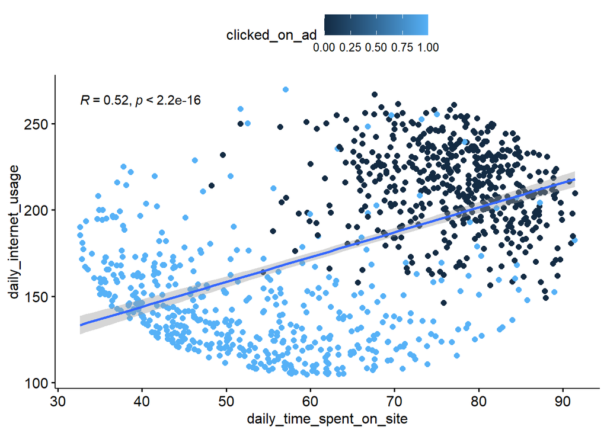

```r
ggscatter(advert1, x = "daily_time_spent_on_site", y = "daily_internet_usage",
          add = "reg.line", conf.int = TRUE,
          cor.coef = TRUE, cor.method = "pearson",
          xlab = "daily_time_spent_on_site", ylab = "daily_internet_usage",  color = "clicked_on_ad")
```

```r
res <- cor.test(advert1$daily_internet_usage, advert1$daily_time_spent_on_site,
                    method = "pearson")
res # Testing the significance of the Pearson correlation coefficients of daily internet usage and time_spent_on_site
```

```
##
##  Pearson's product-moment correlation
##
## data:  advert1$daily_internet_usage and advert1$daily_time_spent_on_site
## t = 19.141, df = 990, p-value < 2.2e-16
## alternative hypothesis: true correlation is not equal to 0
## 95 percent confidence interval:
##  0.4727739 0.5637294
## sample estimates:
##       cor
## 0.5197228
```

The p-value of the test is 2.2e-16, which is less than the significance level alpha = 0.05. We can conclude that daily_internet_usage and daily_time_spent_on_site are significantly correlated with a correlation coefficient of 0.5197228 and p-value of 2.2e-16.

## *Challenging the Solution*

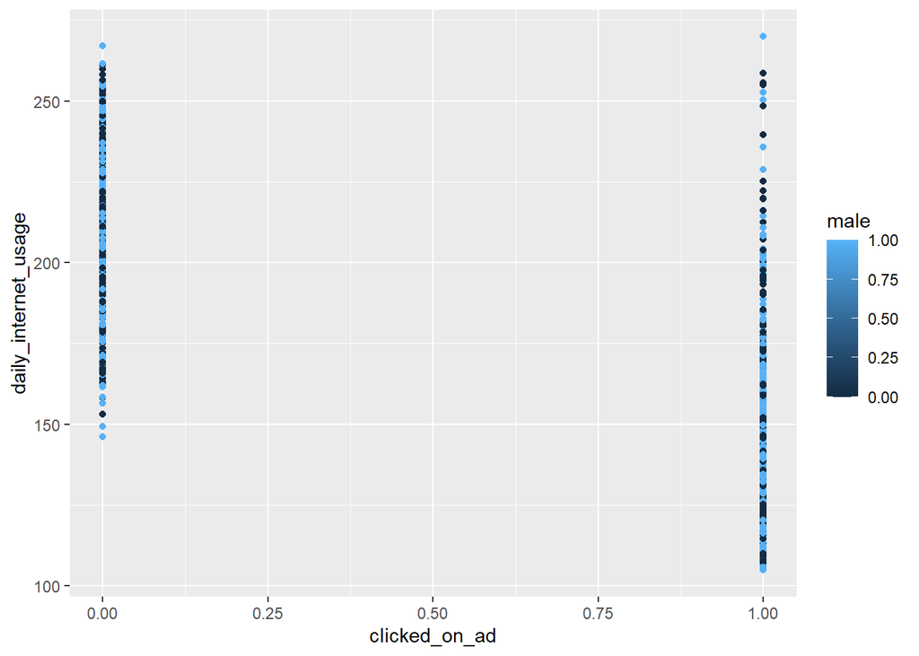

```r
#Checking how people clicked the ad depending on their daily internet usage while showing their gender
ggplot(data = advert1) +
  geom_point(mapping = aes(x = clicked_on_ad, y = daily_internet_usage, color = male))
```

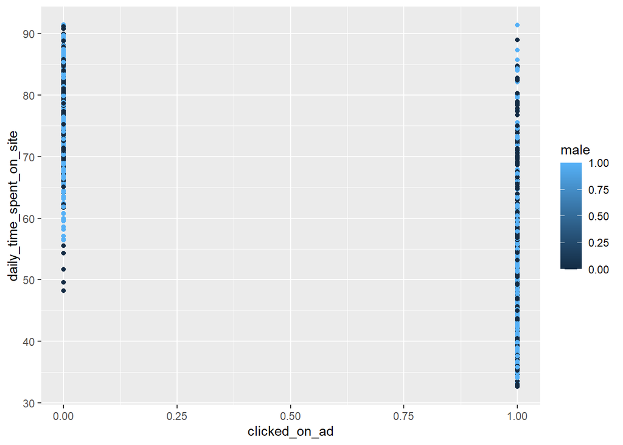

```r
#Checking how people clicked the ad depending on their daily_time_spent_on_site while showing their gender
ggplot(data = advert1) +
  geom_point(mapping = aes(x = clicked_on_ad, y = daily_time_spent_on_site, color = male))
```

Use classifier models such as random forest classifier, Gradient Boosting Classifier, Decision Tree Classifier, naive bayes, XGB Classifier, and Logistic Regression to best predict those that clicked on the ad

## Follow up Questions

*Did we have the right question?*

yes, the research question was clear and specific.

*Did we have the right data?*

Yes, the data was relevant to the project. The dataset was also large enough for us to draw some answers.

*Do we need other data to answer the research question?*

Not necessarily.